# Apunte

## APRENDIZAJE POR REFUERZO

- 5 labs
- HDT 2
- PROYECTO INTERMEDIO
- EXAMEN PRACTICO
- PROYECTO FINAL .

MARTES:

- PRESENCIAL

JUEVES:

- ASINCRONO.

RICHARD S. SUTTON Y ANDREW.

### ¿ PORQUE RL ?

Un modelo supervisado funcionaba asi:

- FOTO DE UN GATITO

  EL MODELO QUIERE VER SI HAY UN GATO O NO.

  ESTO PASABA POR UN MODELO Y TENIA UNA PREDIC.

  LA PREDICCION QUE DIO EL MODELO AHI QUEDA. EL MODELO NO SE VE AFECTADO

POR ENDE LOS DATOS NO SE VEN ALTERADOS.

EN RL

Un estado en un tiempo dado , que se toma una ccion y logicamente me lleva a un estado diferente. Con una recompensa en este tiempo y sigue asi hasta el estado final.

Cada acción cambia el siguiente estado.

Puede ML Supervisado aprender a jugar GO ? : Si pero va a depender de cuantos estados tenga.

Mientras que RL cada acción podemos evaluar para esa foto de ese estado las acciones que desencadenaran mas estados.

#### EJEMPLOS

- Un sistema de trading algoritmico este sistema compra y vende acciones
- Un modelo de lenguaje decide token por token cual respuesta completa la mejor consulta.
- Robot quirurgico , este ajusta la fuerza de las pinzas milimetro a milimetro, esto lo puede ayudar un doctor.
- LLMS. Los asistentntes actuales se refinan bajo supervision de los humanos. HRLFD

Como aprende un sistema cuando el feedback no es instantaneo. Cuando las acciones tienen consecuencias futuras, y no existe un maestro que diga cada paso.

## RL EN EL MAPA DEL APRENDIZAJE.

El aprendizaje por refuerzo va por la interacción. No hay alguien diciendo que si es correcto o no, y este agente toma acciones que modifican el entorno. Entonces las acciones que se desencadenan no pasaron y no se sabe que hubiera pasado.

Una acción mala hoy se manifiesta como una perdida mañana.

El problema de cual de mis desiciones actuales (cuando fue el momento que tome una mala decision.).

### EL CICLO AGENTE - ENTORNO.

AGENTE ----(ACCIONES)-----> ENTORNO

EL entorno responde hacia el agente

AGENTE <----(RECOMPENSA | SIGUIENTE ESTADO)----- ENTORNO

Recompensa se define asi $R_{T+1}$ porque sucede en el siguiente estado.

TRAYECTORIA

$$T: (S_0 , A_0, R1, S_1 , A_1, R2.............S_N , A_N, R_{N+1})$$

S : estado A: accion R: recompensa

#### Propiedad de MARKOV

El estado actual solo depende del estado anterior. La probabilidad de transicionar al estado T+1 dado en el estado que estoy actualmente.

El agente va a observar el estado , selecciona una A segun su politica (es el cerebro del agente), el entorno transiciona al estado siguiente y emite la recompensa correspondiente.

## ESTADO, OBSERVACION Y ESPACIO DE ACCIONES

- Estado $S_t$ : Representacion completa del entorno puede ser inaccesible. Si tuviera acceso a todo el estado. Podriamos predecir la accion siguiente.
- Observacion $O_t$: Lo que el agente realmente percibe es parcial
- Entorno totalmente observable: $O_t = S_t -> MDP$
- Entorno parcialmente observable $O_t != S_t -> POMDP$

## La recompensa

Es el unico canal de comunicación es entre el diseñador y el sistema como tal. La recompensa es que todo objetivo se puede expresar como maximización de recompensa, esperamos que exista una recompensa a futuro. La recompensa es señal de diseño , no dato observado.

La recompensa la decidimos en ese momento.

### Ejemplos

- Banca: +1 si el credito se paga, -1 si entra en mora.
- TELCO: Recompensa proporcional al throughput del canal.
- SALUD: Días sin sintomas como proxy de bienestar del paciente.

Esto tiene desventajas:

- Mal diseño: En una carrera, EL hecho de acelerar nos da puntaje pero no estamos terminando la carrera, Entonces puede entrar en un bucle que acelera pensando que asi gana puntos pero realmente no termina la carrera.

### POLITICA

El aprendizaje por RL busca la mejor politica posible, la politica se denomia con PI y mapea estados a acciones. Esta primera puede ser deterministtica o estocastica

- DETERMINISTICA : Mapea estado a accion
- ESTO CASTICA: Distribución sobre las acciones.

Cuando es deterministica la politica determina la misma acción.

La poltica siempre se optimiza para buscar la mejor.

Evoluciona en el entrenamiento.

## RETORNO EL OBJETIVO A LARGO PLAZO O CORTO PLAZO

Retorno sin descuento , episodios finitos $G_t$

Retorno con descuento $G_t$

El gama esta siendeo elevando al numero de pasos en que estamos. SI gama es 0.9 y recibe una recompensa de 1, su valor actual es de $9^{10}$

Recordemos que el fector de descuento o gama esta en el rango de 0 y 1. Cuanto importa o no el futuro.

Cuando gama es mas cercano a 1 valoramos futuro, cuando es mas cercano a 0 valoramos el presente .

Las funciones de valor al final son herramientas para evaluar una situacion mas una acción. Bajo una poltiica dada , la función de valor ve con la politica pi, con el estado s. Si estoy en el estado s minuscula y sigo la poltica pi cuando tretorno quiero acumular.

Funcion de valor estado V^pi es el retorno esperado siguiendo pi.

Funcion de valor acción Q^pi(s,a) retorno esperado desde s tomando a, luego siguiendo pi.

### Comparación

En cuento a la señal de aprendizaje del lado supervisado tenemos una etiqueta, y del rl tenemos la recompensa escalable.

# CLASE 14 DE JULIO DEL 2026

## Multii Armed Bandit

El problema base que introduce el RL es este el del nombre que ves ahi arriba , QUE NO LEEES .

Pongamos como ejemplo NETFLIX

Netflix te muestra

- Miniatura
- Nombre
- Ratings

Cada serie tiene n miniaturas para mostrar a cada persona diferente.

El modelo que tiene es un modelo de recomendación que usa RL.

Cual es la que mejor tiene una mejor conversión:

Un banco ofrece tres tasas de credito:

- Cual maximiza conversión sin perder rentabilidad.

Cada oferta tiene su optima un costo real.

Entonces en donde esta el problema si ya dimos ejemplos ?

ESTE SE LLAMA **EXPLORACION DEL AN....** **EXPLORACION EXPLOTACION**

Formaliza en que probar cuesta oportunidad, y no probar cuesta ignorancia.

Digamos que elegimos un atajo para llegar a la U, ese atajo nos ha ayudado mucho. Pero uno se pregunta si hay otro camino mas eficiente. Entonces la cosa es ir probando, y con ello viene un costo asociado. Por el contrario cuando hemos recabado de los experimentos. Por ello entra el dilema el experimentar y explorar y que tanto debemos de usar la información que tiene ya a favor.

Esto quiere decir que si el algoritmo elige explorar puede que valga vrg, y si no elige explorar puede que no este en el mas optimo.

## Formalizacion de k-armed bandit

- k acciones , cada una con sitribucion de recompensa desconocida.
- Valor verdadero de la acción a: q*(a) = E[Rt | At = a]
- Si lo conociera obvio lo eligo. Lo que si puedo hacer es estimar

En cada paso del tiempo el agente elige una acción A y lo que queremos es maximizar esa elección y recompensa.

Aqui entra el problema que tanto debemos de explorar o explotar para tener siempre la mejor recompensa.

En cada paso del tiempo el agente elige un accionar dentro de una recompensa y el agente actualiza su estimación

- Objetivo

### El dilema exploracion-explotacion

- Explotacion es elegir la accion con mayor estimado actual Qt(a)
- Exploracion: Elegir otra acción para mejorar las estimaciones.

A^*_t = argmax Qt(a)

Si el agente usa la accion avariciosa (como un prro judio) es una accion greddy y esta explotando.

La exploración elige todo a lo random. Si el agente elige una acción no greddy.

Pero puede descubrir una acción que creia mala pero era buena.

- No se puede hacer ambas simultaneamente en el mismo paso.
- Equilibrar este trade off es el problema central de bandido.

El dilema filosofico es ser un judio(explotador) o un niño hiperactivo (exploracion) .

El numerador es la suma de todas las recompensas en los que elegimos la acción A.

[figure not shown]

Entonces lo que puede pasar es que las exploraciones al ser muy grandes no este explorando .

### Metodo gredy puro.

[figure not shown]

Esto maximiza la recompensa inmediata. No vamos a ver nuevas acciones no elegidas . Y solo ese vamos a seguir usando .

Si la distribución inicial es mala, el agente quedara en una opción suboptima asi que debemos de ver cuales es la mejor inicial.

El agente graeedy no converge , necesariamente a la acción optima.

### Metodo e greddy

[figure not shown]

EL metodo epsilo gredy introduce un parametro epsilon que el agente decide explotar o explota.

Osea que al aazar elige si explorar o explotar.

Con un epsilon 0 es explotar, igual a 1 es exploración.

En la practica esta en 0.01 y 0.1

Durante las primeras iteraciones hacemos exploracion luego hacemos explotamos. y al final solo explotacion osea negrear.

[figure not shown]

En deep learning buscamos que la perdida sea pequeña, esto es similar solo que en lugar de decir que hay una perdida, esta acción optima asumiendo que la tenemos es como tuvieramos nuestro y miralo asi

Delta a = a_* (a*) - q*(a)

es y - y^

Actualización incremental de estimaciones.

La formula de promedio que vimos antes debemos de guardar todas las recompensas historicas.

es esta madre.

[figure not shown]

EL numerador es la suma de todas las recompensas, el indicador 1 es si tomamos esa acción en ese momento, dividido en las veces que tomamos esa acción.

Solo que en sistemas enormes es muy costoso.

Debemos de tener una actualización incremental equivalente.

La actualización se hace sin necesidad de guardar un historial .

Nosotros podemos decir que el valor Q_1 el valor Q es el que nos dice que tan buena es la acción como tal.

Q_n es el estiamos de n-1 recompensas.

Esto seria resumido aqui

[figure not shown]

Qn+1 es una nueva estimación para la nueva recompensa. Es igual a la Q mas un termino de corrección que es el alpha (Recompensa - Paso anterior) Esa resta es el error de la estimación.

### Bandits no estacionarios.

Hasta ahora asumimos que el valor estimado no cambia con el tiempo. Pero si cambia se comporta de manera diferente.

[figure not shown]

Las acciones cambian en el tiempo, asmir que todo es igual falla en escenarios reales. El promedio muestral es que no le podemos dar el mismo peso a las observaciones historicas. En el calculo una recompensa hace bastante tiempo se toma igual que una ahora.

[figure not shown]

La solucion es usar una constante alpha muestra lo que ocurre si expandimos la regla de manera recursiva. La estimación actual es la suma ponderada de todas las recompensas pasadas , las mas recientes un mayor peso y las mas antiguas un menor peso.

[figure not shown]

El metodo elige sin considerar la incertidumbre ,explorar una acción visitada hace 100 veces es igual que una que nunca fue visitada.

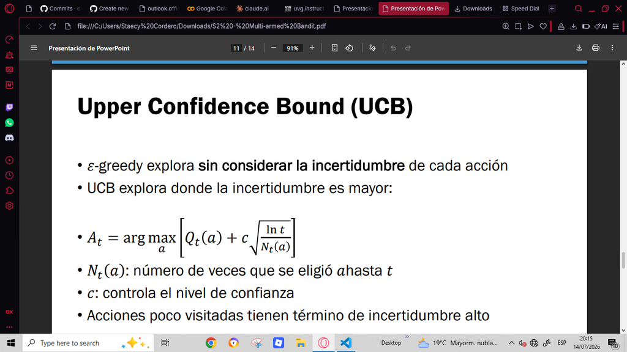

Este corrige este problema de explorar sin considerar la incertidumbre y tener un principio de optimismo.

Cuando no sabemos cuanto vale una acción asumimos la mejor posible. El Qt (a) es la estimación actual de la acción. y se le suma lo de C es nuestro bono por incertidumbre el Nt(a) es el numero de veces que la accion fue elegida, eso quere decr que se elgo no necestamos volverlo a explorar sno se exploro muchas veces entonces la ncertdumbre sera grande.

Vamos a tener accones que nunca vamos a vstar y por ende desprestgamos a lo largo de tempo es darle mas oportundad aquellas que no han sdo vstas .

# CLASE 21 DE JULIO

## MARKOV DESICION PROCESS.

Como se que es tomar una buena desición:

Limitaciones del bandidos:

El gbandido cada accion es independiente, no hay estado que cambie. Un MDP es una tupla (S,A,p,r,y)

Esta conformada por 5 objetos, primero S es el espacio de estados.

A espacio de acciones

p(s', | s, a) funcion de transicion, propbabilidad de llegar al siguiente estado o s' tomado a.

r(s,a,s') funcion de recompensa esperada.

Esta función de recompensa es la seññal de diseño que tiene una función de origen y estado destino.

Y finalmente tenemos la propiedad que le da nombre la modelo que es el factor de descuento:

y pertenece a [0,1) factos de descuento

Depende del estado actual y la acción que tomo , NO DEPENDE DEL HISTORIAL SINO DEL ESTADO ACTUAL Y LA SIGUIEINTEE. TIENE EL SUFICIENTE CONTEXTO PARA ENTENDER QUE LA ACCION ACTUAL ES EL HISTORIAL COMO TAL.

El estado actual contiene la onfirmacion relevante del pasado.

No necesitamos guardar el pasado sino solo el presente .

Si la propieda falla : el estado mal definido , no el mundo .

Diseñar buen estado es diseñar buena representación.

La propiedad de markov es en cierto sentido la versión de ese sistema.

La tarea mas importante es :"MI REPRESENTACION DE ESTADO CAPTURA TODO PARA QUE LA APROXIMACIÓN DE MARKOV SE APROXIME RAZONABLEMENTE. "

La politica es pi (a | s) probaibilidad de tomar a en el estado s

Funcion de valor de estado : Y sigo la politica que tengo definida de aqui a la eternidad, cuanto retorno acumulare, es una medida que tan buena es una situación bajo una politica dada

Funcion de accion: La segunda es la politica de vida ya esta definida como es la anterior. Y la diferencia de la segunda es que fuerzo la primera acción, osea es empezar entregando algo al inicio y luego tomar la politica de manera individual

El problema del RL , es secontrar la potlica optima en el setido que de el mayor retorno esperado. La politica optima es decir que ahorita tomo la mejor acción y las siguientes en algun punto tomando buenas acciones encontrare la mejor de todas .

Alemnos existe una politica deterministica optima .

## ECUACION BELLMAN PARA Vpi

Cada algoritmo en este curso , es en escencia una forma de aproximar esta ecuación. El lado izquierdo lo que nos dice b de pi de s. Es el valor esperado

**BELLMAN EVALUA }QUE TAN BUENO ES ESTE ESTADO CONSIDERANDO LAS POSIBILIDADES SIGUIENTES. **

Es una forma que tratamos de destilar el futuro completo en un numero.

SE LE NOMBRE PRINCIPIO DE OPTIMALIDAD, Eso quiere decir que respecto al estado actual y el anterior siempre elegir la politica optima.

Si te refieres a **Procesos de Decisión de Markov (MDP)** y **Aprendizaje por Refuerzo**, la respuesta es la siguiente:

### ¿Cuál es el valor máximo que podemos extraer independientemente de la política?

El valor máximo que podemos obtener de un estado es el que proporciona la **política óptima**. Este valor se representa mediante la **función de valor óptima**, la cual indica la mayor recompensa esperada que puede alcanzarse desde un estado determinado.

La función de valor óptima se define como:

$$ V^*(s)=\max_{\pi} V^{\pi}(s) $$

donde:

- (V^*(s)): valor óptimo del estado (s).
- (\pi): cualquier política posible.
- (V^{\pi}(s)): valor del estado (s) al seguir la política (\pi).

Esto significa que, entre todas las políticas posibles, se selecciona aquella que produce la mayor recompensa esperada.

## La ecuación de optimalidad de valor (Ecuación de Bellman)

La ecuación de Bellman para la función de valor óptima es:

$$ V^*(s)=\max_{a}\sum_{s',r} p(s',r \mid s,a)\left[r+\gamma V^*(s')\right] $$

### Explicación de la ecuación

Esta ecuación indica que el valor óptimo de un estado es igual a la **mejor acción posible** que puede realizar el agente, considerando:

- $$\max_a$$: selecciona la acción que maximiza la recompensa esperada.
- $$p(s',r \mid s,a)$$: probabilidad de llegar al estado (s') y recibir la recompensa (r) al ejecutar la acción (a) desde el estado (s).
- $$r$$: recompensa inmediata obtenida después de realizar la acción.
- $$\gamma$$: factor de descuento, con (0 \leq \gamma \leq 1), que determina cuánto se valoran las recompensas futuras.
- $$V^*(s')$$: valor óptimo del siguiente estado.

En otras palabras, la ecuación evalúa todas las acciones disponibles, calcula la recompensa inmediata más el valor futuro descontado para cada una y elige la acción que proporciona el mayor valor esperado.

También puede expresarse mediante la función de acción-valor óptima:

$$ Q^*(s,a)=\sum_{s',r} p(s',r \mid s,a)\left[r+\gamma \max_{a'}Q^*(s',a')\right] $$

donde:

- $$Q^*(s,a)$$ representa el valor óptimo de ejecutar la acción (a) en el estado (s).
- $$\max_{a'}Q^*(s',a')$$ corresponde al mejor valor que puede obtenerse en el siguiente estado. Esta formulación es la base de algoritmos como **Q-Learning**.

La ecuación optima de q es mas directa. Si conozco el Q* que es el q optimo, la politica actual es la que mejor se encontrara. La acción que se maximiza Q sirve para saber la función en la cual puedo actuar.

La diferencia entre ecuaciones de evaluación y optimalidad es el maximo. Ese operador rompe con la linealidad del sistema. Necesitamos metodos iterativos para converger al analisis que necesitamos.

La ecuación asume que la gente toma mejor las acciones desde el momoento actual en adelante.